# Gibbs Sampler Pt.1

Jeff Gould

5/10/2021

First we build a Gibbs-MH Sampler on the Heston Model, using non-informative/flat priors for each parameter:

We are able to get a closed form solution for $\xi^2$, but need to use an MH step for $\omega$ and $\theta$

Log-likelihood functions for $\omega$ and $\theta$ are the same:

$$\log L = - \frac{1}{2\xi^2} \sum \frac{(V_t - \theta(\omega - V_t))^2}{V_t}$$

Since Heston defines $omega$ as the long-run mean of the variance, we sample $\omega$ from a normal distribution centered at $\bar{\omega}$. As $\theta$ is a rate parameter bounded between $(0,1)$, we sample $\theta$ from a $beta$ distribution, with parameters tuned to get a desired acceptance rate and accuracy

```r
btc_candles <- read_csv("btcOpenCandles.csv") %>%
  mutate(dVt = lead(AnnualizedRV) - AnnualizedRV) #%>%
  # mutate(logAnnualRV = log(AnnualizedRV),
  #        dYt = lead(logAnnualRV) - logAnnualRV)

train <- btc_candles %>%
  filter(time < as.Date("2019-07-01"))

test <- btc_candles %>%
  filter(time >= as.Date("2019-07-01"))

Vt <- train$AnnualizedRV
dVt <- train$dVt

logL_omega <- function(Omega, Theta, Xi, .dVt = dVt, .Vt = Vt){
  -1 / (2 * Xi^2) * sum(((.dVt - Theta * (Omega - .Vt))^2) / .Vt)
}
logL_theta <- function(Theta, Omega, Xi,  .dVt = dVt, .Vt = Vt){
  -1 / (2 * Xi^2) * sum(((.dVt - Theta * (Omega - .Vt))^2) / .Vt)
}

burnIn <- 5000
thin <- 10
keep <- 1000
B <- burnIn + keep * thin

omega <- vector("numeric", B)
xi <- vector("numeric", B)
theta <- vector("numeric", B)

omega[1] = mean(Vt)
xi[1] = sd(Vt)^2
theta[1] = 0.25

n <- length(Vt)

omega_accept <- 0
theta_accept <- 0
set.seed(111)
for (b in 2:B) {

  phi_alpha <- n/2
  phi_beta <- sum((dVt - theta[b-1]*(omega[b-1] - Vt))^2 / (2*Vt))

  phi <- MCMCpack::rinvgamma(1, phi_alpha, phi_beta)
  xi[b] = sqrt(phi)

  U <- runif(1)
  ## MH for omega
  omega_star <- rnorm(1, mean = mean(Vt), sd = 1.5*sd(Vt))

  r <- exp(logL_omega(omega_star, theta[b-1], xi[b-1]) - logL_omega(omega[b-1], theta[b-1], xi[b-1]))
  if(U < min(r,1)){
    omega[b] = omega_star
    if(b > burnIn){
      omega_accept <- omega_accept + 1
    }
  }else{
    omega[b] = omega[b-1]
  }
  ## MH for theta
  theta_alpha = 4.5
  theta_beta = 9
  theta_star <- rbeta(1, theta_alpha, theta_beta)

  r <- exp(logL_theta(theta_star, omega[b-1], xi[b-1]) - logL_omega(theta[b-1], omega[b-1], xi[b-1])) *
    (dbeta(theta[b-1], theta_alpha, theta_beta) / dbeta(theta_star, theta_alpha, theta_beta))
  if(U < min(r,1)){
    theta[b] = theta_star
    if(b > burnIn){
      theta_accept <- theta_accept + 1
    }
  }else{
    theta[b] = theta[b-1]
  }

}
```

Check output diagnostics:

```r
theta_accept / B
```

```
## [1] 0.6352667
```

```r
omega_accept / B
```

```
## [1] 0.0742
```

```r
mean(omega[-c(1:burnIn)])
```

```
## [1] 0.5961431
```

```r
mean(Vt)
```

```
## [1] 0.6762868
```

```r
mean(theta[-c(1:burnIn)])
```

```
## [1] 0.3298711
```

```r
mean(xi[-c(1:burnIn)])
```

```
## [1] 0.5244325
```

```r
sd(Vt)
```

```
## [1] 0.5750542
```

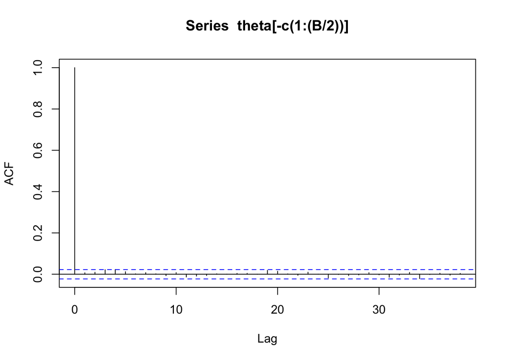

```r
acf(theta[-c(1:(B/2))])
```

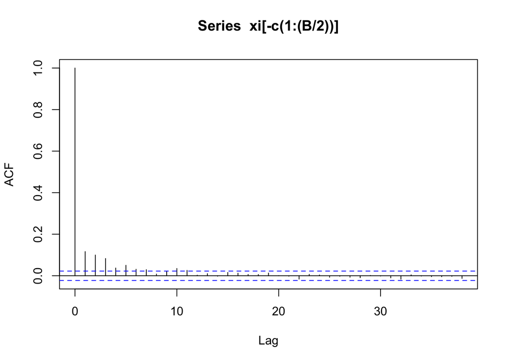

```r
acf(xi[-c(1:(B/2))])
```

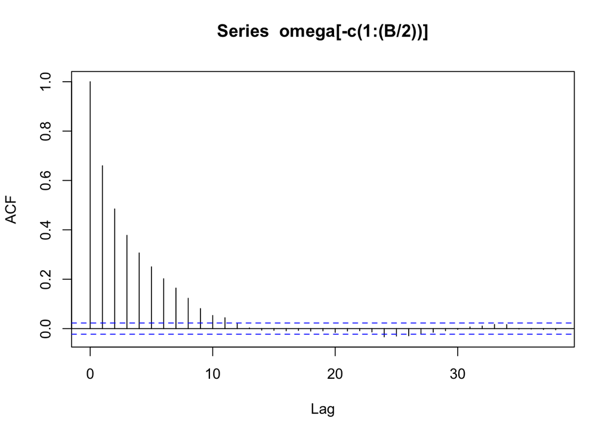

```r
acf(omega[-c(1:(B/2))])
```

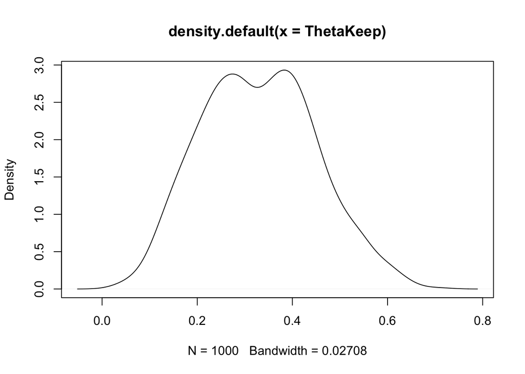

```r
keepIdx <- seq(burnIn+1, B, by = thin)
ThetaKeep <- theta[keepIdx]
OmegaKeep <- omega[keepIdx]
XiKeep <- xi[keepIdx]

plot(density(ThetaKeep))
```

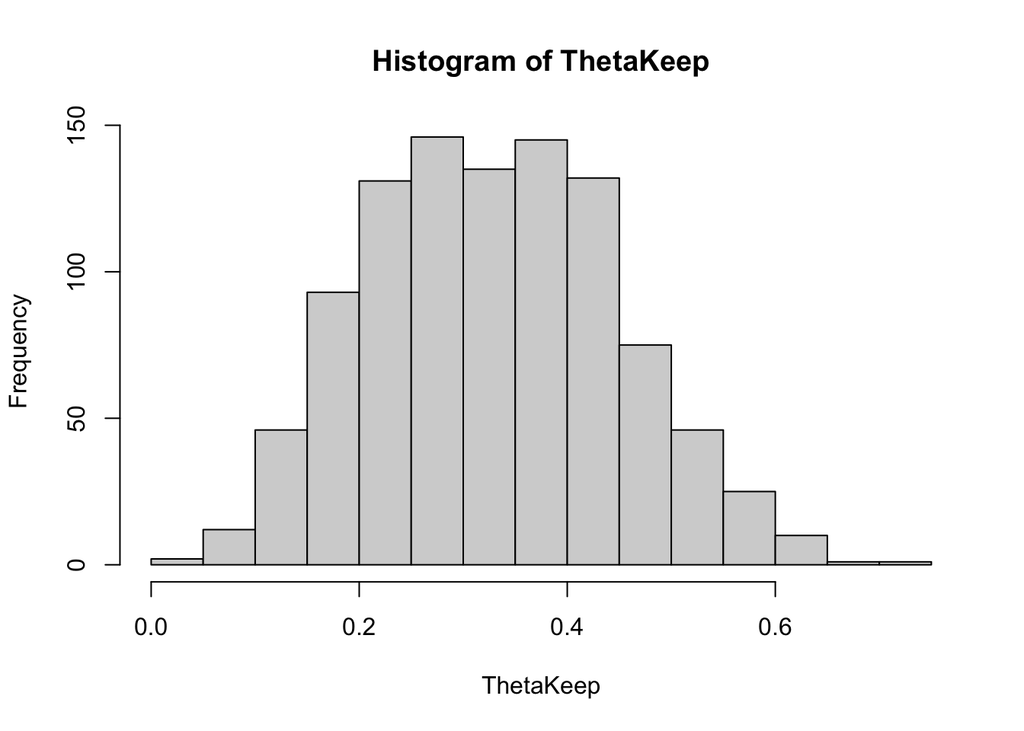

```r
hist(ThetaKeep)
```

```r
mean(OmegaKeep)
```

```
## [1] 0.5927294
```

```r
median(OmegaKeep)
```

```
## [1] 0.5793307
```

Now do a check to see how well the estimated parameters and underlying model capture the actual change in variance:

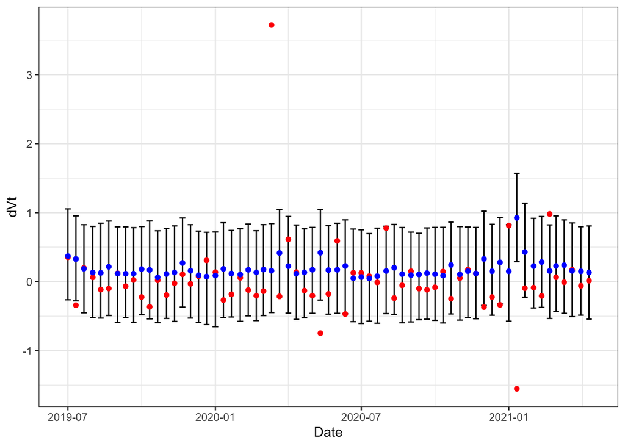

```r
HestonModel <- function(dBt, theta, omega, Vt, xi){
  return(
    theta * (Vt - omega) + xi * sqrt(Vt) * dBt
  )
 }
# ItoHestonModel <- function(dBt, theta, omega, Vt, xi){
#   return(
#    (theta * (omega - Vt) - xi^2)/Vt + xi / sqrt(Vt) * dBt
#   )
# }

simDVT <- function(Vt_i, theta, omega, xi, date, dBt = NULL, sims = 1000){
  if(is.null(dBt)) dBt <- rnorm(sims)

  dYt <- t(sapply(dBt, HestonModel, Vt_i, theta, omega, xi)) %>% as.data.frame()
  dYt$Date = date
  return(dYt)

}


ParamsDf <- data.frame(theta = mean(ThetaKeep),
                       omega = mean(OmegaKeep),
                       xi = mean(XiKeep)) %>%
  expand_grid(test%>% select(time, AnnualizedRV)) %>%
  rename(date = time,
         Vt_i = AnnualizedRV)

testSim <- pmap_dfr(ParamsDf, simDVT)

checkResults <- testSim %>%
  pivot_longer(cols = V1:V1000, values_to = "simDVt") %>%
  select(-name) %>%
  left_join(test %>% select(Date = time, dVt, AnnualizedRV))

checkResults %>%
  group_by(Date) %>%
  mutate(upper = quantile(simDVt, 0.95),
         lower = quantile(simDVt, 0.05),
         pointEst = median(simDVt)) %>%
  filter(lubridate::day(Date) %in% c(1,11,21)) %>%
  select(-simDVt) %>%
  distinct() %>%
  # ggplot(aes(x = AnnualizedRV)) +
  # geom_point(aes(y = pointEst), col = "red") +
  #geom_point(aes(y = dVt), col = "blue")
  ggplot(aes(x = Date)) +
  geom_errorbar(aes(ymin = lower, ymax = upper)) +
  geom_point(aes(y = dVt), col = "red")  +
  geom_point(aes(y = pointEst), col = "blue") +
  theme_bw()
```

#### Ignore this

Do the same thing as above, except instead of using raw $V_t$, we take $\log(10*V_t)$ as our volatility parameter. The $\log$ transformation is because volatility follows a log-normal distribution, and the scaling of 10 is to prevent non-negative values so we can keep our Gibb-Sampling step with $\xi$. We will use $dY_t$ to denote the transformed variance